# PD6

Dominik Rafacz

26 - 05 - 2019

# 1 Wstęp

W niniejszym raporcie będziemy badać indeksy oceniające skuteczność klasteryzacji. Pochodzą one z [niniejszego artykułu](https://www.researchgate.net/publication/2500099_On_Clustering_Validation_Techniques).

Będziemy korzystać z klasteryzacji hierarchicznej `hclust` (metoda `ward.D`) oraz algorytmu `kmeans`. Klasteryzacji dokonamy na syntetycznym zbiorze [s2](http://cs.joensuu.fi/sipu/datasets/). Zbiór ten jest dwuwymiarowy i posiada 15 klastrów:

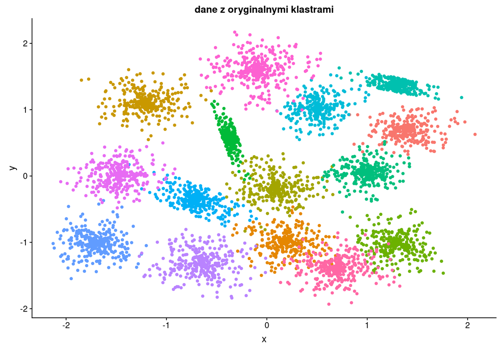

```r
dataset <- cbind(read.csv2("s2.data", sep = " ",
                           col.names = c("x", "y"),
                           header = FALSE),
                 read.csv2("s2.labels",
                           col.names = "label",
                           header = FALSE))
dataset$x <- scale(dataset$x)
dataset$y <- scale(dataset$y)

# plotting:

ggplot(data = dataset, aes(x = x, y = y, color = as.factor(label))) +
  geom_point(show.legend = FALSE) +
  ggtitle("dane z oryginalnymi klastrami")
```

# 2 Klasteryzacja

Teraz dokonamy kalsteryzacji oboma algorytmami z różną liczbą klastrów (`k`) - od 2 do 20 - i zwizualizujemy efekty:

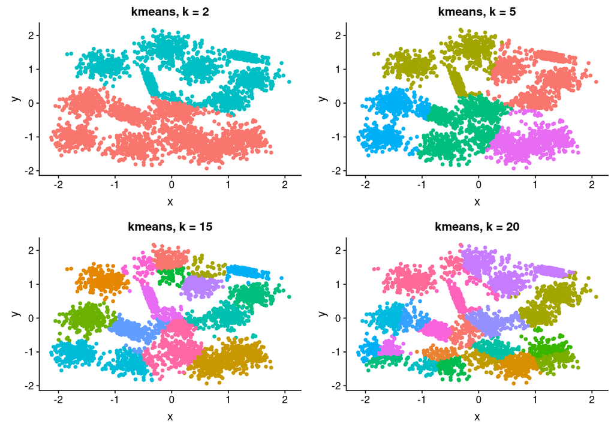

```r
par(mfrow = c(2,2))

kmeans_partitioning <- lapply(2:20, function(clust_num) kmeans(dataset[, 1:2], clust_num))

plot_grid(plotlist = lapply(c(1,4,14,19), function(k) {
  ggplot(data = dataset, aes(x = x, y = y, color = as.factor(kmeans_partitioning[[k]]$cluster))) +
    geom_point(show.legend = FALSE) +
    ggtitle(paste0("kmeans, k = ", k+1))
}), nrow = 2)
```

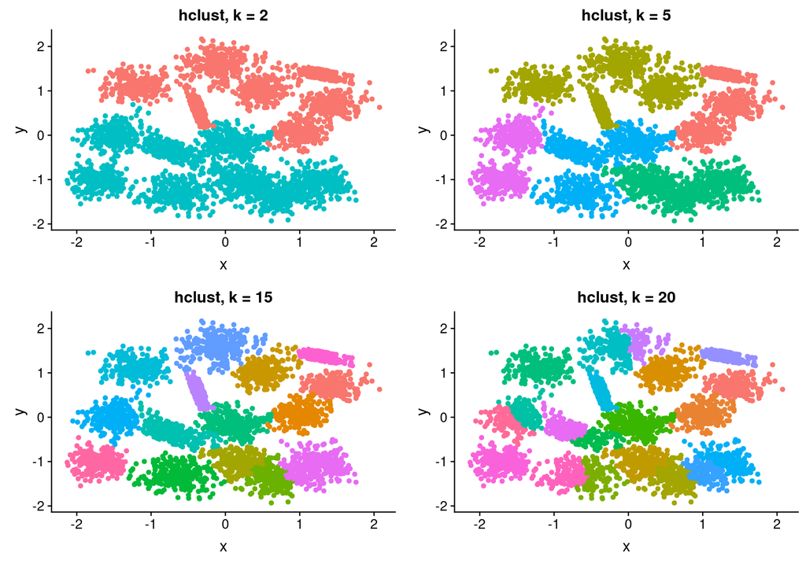

```r
hclust_tree <- hclust(dist(dataset[, 1:2]), method="ward.D")
hclust_partitioning <- lapply(2:20, function(clust_num) cutree(hclust_tree, k=clust_num))

plot_grid(plotlist = lapply(c(1,4,14,19), function(k) {
  ggplot(data = dataset, aes(x = x, y = y, color = as.factor(hclust_partitioning[[k]]))) +
    geom_point(show.legend = FALSE) +
    ggtitle(paste0("hclust, k = ", k+1))
}), nrow = 2)
```

# 3 Indeksy

Teraz dla każdej z klasteryzacji wyliczymy zestaw indeksów:

- statystykę Randa,
- współczynnik Jaccarda,
- indeks Folkesa-Mallowsa,
- indeks Dunna,
- indeks Gamma,
- indeks Daviesa-Bouldina.

Pierwsze trzy wyliczymy za pomocą własnej implementacji funkcji na podstawie artykułu, pozostałe trzy natomiast korzystając z funkcji `intCriteria` z pakietu `clusterCrit`.

```r
calculate_pairs <- function(C_parts, P_parts) {
  N <- length(C_parts)
  same_C_matrix <- outer(C_parts, C_parts, function(xi, xj) xi == xj)
  same_P_matrix <- outer(P_parts, P_parts, function(xi, xj) xi == xj)

  ss_matrix <- same_C_matrix & same_P_matrix & upper.tri(same_C_matrix)
  sd_matrix <- same_C_matrix & !same_P_matrix & upper.tri(same_C_matrix)
  ds_matrix <- !same_C_matrix & same_P_matrix & upper.tri(same_C_matrix)
  dd_matrix <- !same_C_matrix & !same_P_matrix & upper.tri(same_C_matrix)

  c(a = sum(ss_matrix), b = sum(sd_matrix), c = sum(ds_matrix), d = sum(dd_matrix))
}

calculate_external_indicies <- function(C_parts, P_parts) {
  bs <- calculate_pairs(C_parts, P_parts)
  N <- length(C_parts)
  M <- N*(N-1)/2
  inds <- numeric()
  inds["Rand_Statistic"] <- (bs["a"] + bs["d"])/M
  inds["Jaccard_Coefficient"] <- bs["a"]/(bs["a"] + bs["b"] + bs["c"])
  inds["Folkes_and_Mallows_index"] <- bs["a"] /
    sqrt(as.numeric(bs["a"] + bs["b"]) *
           as.numeric(bs["a"] + bs["c"]))
  #how to calculate Huberts_Gamma_index?
  # how to calculate cpcc
  inds
}

calculate_all_indicies <- function(dataset, P_parts, hclust_partitioning, kmeans_partitioning) {
  maxclust <- 19
  method <- rep(c("hclust", "kmeans"), each = maxclust)
  k <- rep(2:(maxclust+1), 2)
  ret <- data.frame(method = method, k = k)
  for(k in 1:maxclust) {
    C_parts <- hclust_partitioning[[k]]
    ret[k, c("Rand", "Jaccard", "Folkes-Mallows", "Dunn", "Gamma", "Davies-Bouldin")] <-
      c(calculate_external_indicies(C_parts, P_parts),
        unlist(clusterCrit::intCriteria(
          as.matrix(dataset),
          C_parts,
          c("Dunn", "Gamma", "Davies_Bouldin"))))
    C_parts <- kmeans_partitioning[[k]]$cluster
    ret[k + maxclust, c("Rand", "Jaccard", "Folkes-Mallows", "Dunn", "Gamma", "Davies-Bouldin")] <-
      c(calculate_external_indicies(C_parts, P_parts),
        unlist(clusterCrit::intCriteria(
          as.matrix(dataset),
          C_parts,
          c("Dunn", "Gamma", "Davies_Bouldin"))))
  }
  ret
}

inds <- calculate_all_indicies(dataset[,1:2], dataset$label,
                      hclust_partitioning, kmeans_partitioning)
```

## 3.1 hclust

```r
inds %>%
  filter(method == "hclust") %>%
  kable() %>%
  kable_styling(bootstrap_options = "striped", full_width = F)
```

| method | k | Rand | Jaccard | Folkes-Mallows | Dunn | Gamma | Davies-Bouldin |
| --- | --- | --- | --- | --- | --- | --- | --- |
| hclust | 2 | 0.5620133 | 0.1310098 | 0.3605591 | 0.0100165 | 0.6236742 | 1.0746617 |
| hclust | 3 | 0.6971720 | 0.1780593 | 0.4193137 | 0.0101402 | 0.6981656 | 0.8424038 |
| hclust | 4 | 0.7986909 | 0.2451259 | 0.4915867 | 0.0134164 | 0.8009910 | 0.8157062 |
| hclust | 5 | 0.8544751 | 0.3081014 | 0.5498225 | 0.0141532 | 0.8445635 | 0.9072834 |
| hclust | 6 | 0.8896671 | 0.3692851 | 0.6018885 | 0.0167550 | 0.8757350 | 0.9272938 |
| hclust | 7 | 0.9091473 | 0.4155536 | 0.6389444 | 0.0173121 | 0.8971228 | 0.7963698 |
| hclust | 8 | 0.9253022 | 0.4626884 | 0.6739737 | 0.0173121 | 0.9139163 | 0.7453677 |
| hclust | 9 | 0.9343357 | 0.4942151 | 0.6965380 | 0.0185634 | 0.9247975 | 0.6939739 |
| hclust | 10 | 0.9422971 | 0.5265021 | 0.7193841 | 0.0185634 | 0.9342245 | 0.6029439 |
| hclust | 11 | 0.9577575 | 0.5969347 | 0.7636408 | 0.0142606 | 0.9523811 | 0.6138357 |
| hclust | 12 | 0.9673155 | 0.6561447 | 0.8018922 | 0.0142606 | 0.9641895 | 0.5887051 |
| hclust | 13 | 0.9759434 | 0.7205750 | 0.8418611 | 0.0157884 | 0.9789123 | 0.5292320 |
| hclust | 14 | 0.9834007 | 0.7888391 | 0.8831732 | 0.0157884 | 0.9841583 | 0.4946761 |
| hclust | 15 | 0.9888547 | 0.8460109 | 0.9165863 | 0.0181728 | 0.9896854 | 0.4815562 |
| hclust | 16 | 0.9888858 | 0.8433378 | 0.9151746 | 0.0181728 | 0.9891201 | 0.5511118 |
| hclust | 17 | 0.9875583 | 0.8235807 | 0.9038441 | 0.0188823 | 0.9885345 | 0.6037261 |
| hclust | 18 | 0.9855642 | 0.7949234 | 0.8870673 | 0.0188823 | 0.9882362 | 0.6861517 |
| hclust | 19 | 0.9838263 | 0.7699789 | 0.8722197 | 0.0135030 | 0.9884419 | 0.7473337 |
| hclust | 20 | 0.9819165 | 0.7422157 | 0.8555246 | 0.0135030 | 0.9874317 | 0.8183545 |

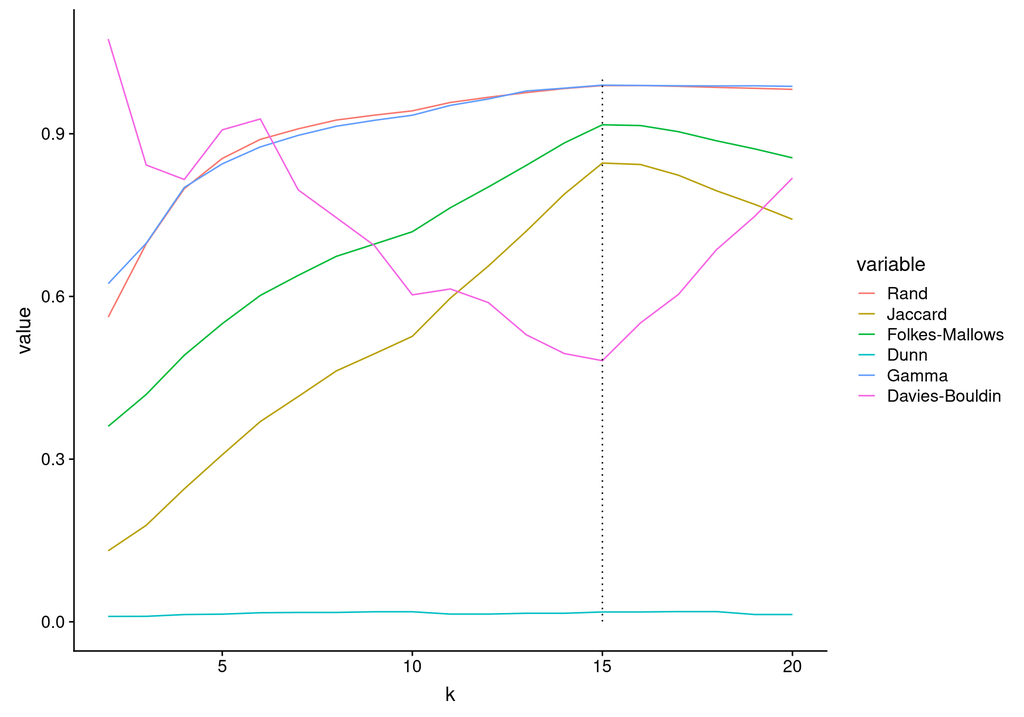

```r
ggplot(data = inds %>%
         filter(method == "hclust") %>%
         select(-method) %>% melt(id.vars = "k"),
       aes(x = k, y= value, color = variable)) +
  geom_line() +
  geom_line(data = data.frame(x = c(15,15), y = c(1, 0)), aes(x = x, y = y),
            linetype = "dotted", inherit.aes = FALSE)
```

Możemy zauważyć, że indeksy są całkiem zgodne, co do wyboru optymalnego parametru *k*, czyli liczby klastrów – jedynie indeks Dunna wskazuje na sugerowaną wartość *k* równą 17 lub 18 (indeksy Randa, Jaccarda, Folkesa-Mallowsa, Dunna oraz indeks gamma chcemy maksymalizować, indeks Daviesa-Bouldina minimalizować). Z wykresu całkiem wyraźnie wynika, że optimum znajduje się w 15 lub 16. Ponadto chciałbym wyróżnić kilka obserwacji:

- Indeksy Randa i gamma przyjmują bardzo bliskie sobie wartości,
- Indeks Dunna przyjmuje w tym przypadku wartości bardzo bliskie zera ($<0.02$),
- Indeksy Jaccarda i Folkesa-Mallowsa mają bardzo podobną zmienność, ich wykresy wyglądają (w przybliżeniu) jak przesunięte o stałą.

Przyjrzyjmy się jeszcze indeksowi Dunna w przybliżeniu:

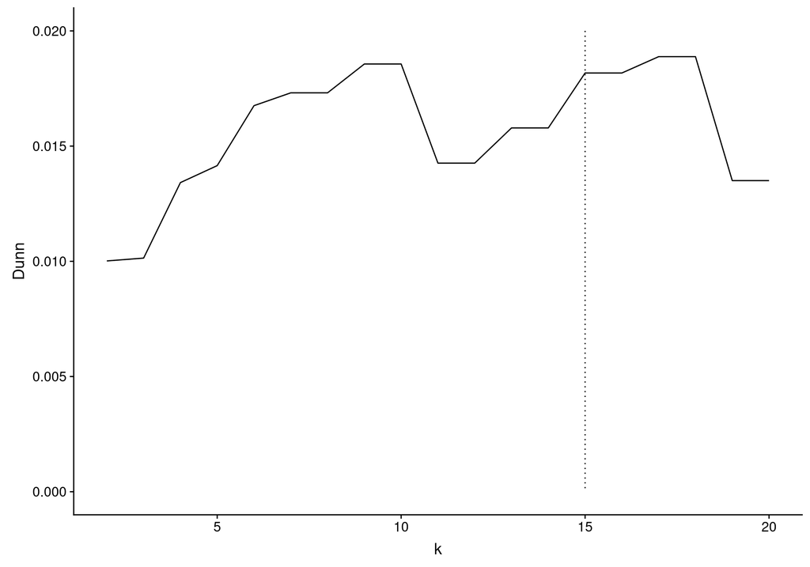

```r
ggplot(data = inds %>%
         filter(method == "hclust"),
       aes(x = k, y= Dunn)) +
  geom_line() +
  geom_line(data = data.frame(x = c(15,15), y = c(0.02, 0)), aes(x = x, y = y),
            linetype = "dotted", inherit.aes = FALSE)
```

Widać, że dla *k* $=11, \dots, 16$ indeks zachowuje się odmiennie od pozostałych.

## 3.2 kmeans

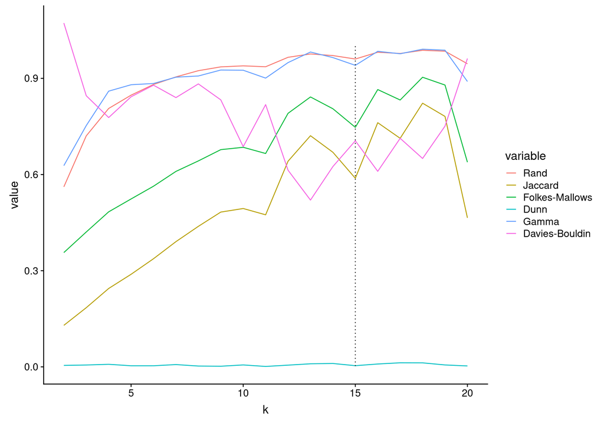

```r
ggplot(data = inds %>%
         filter(method == "kmeans") %>%
         select(-method) %>% melt(id.vars = "k"),
       aes(x = k, y= value, color = variable)) +
  geom_line() +
  geom_line(data = data.frame(x = c(15,15), y = c(1, 0)), aes(x = x, y = y),
            linetype = "dotted", inherit.aes = FALSE)
```

```r
inds %>%
  filter(method == "kmeans") %>%
  kable() %>%
  kable_styling(bootstrap_options = "striped", full_width = F)
```

| method | k | Rand | Jaccard | Folkes-Mallows | Dunn | Gamma | Davies-Bouldin |
| --- | --- | --- | --- | --- | --- | --- | --- |
| kmeans | 2 | 0.5615224 | 0.1294805 | 0.3565248 | 0.0045303 | 0.6276972 | 1.0725058 |
| kmeans | 3 | 0.7205916 | 0.1845885 | 0.4207049 | 0.0057552 | 0.7526811 | 0.8457529 |
| kmeans | 4 | 0.8060709 | 0.2445023 | 0.4835853 | 0.0079595 | 0.8600878 | 0.7777295 |
| kmeans | 5 | 0.8475813 | 0.2888062 | 0.5238040 | 0.0033971 | 0.8800523 | 0.8425739 |
| kmeans | 6 | 0.8809197 | 0.3373529 | 0.5635457 | 0.0034027 | 0.8839656 | 0.8786349 |
| kmeans | 7 | 0.9044959 | 0.3906194 | 0.6097225 | 0.0071162 | 0.9036260 | 0.8399531 |
| kmeans | 8 | 0.9239115 | 0.4383252 | 0.6424502 | 0.0025211 | 0.9073859 | 0.8826418 |
| kmeans | 9 | 0.9357948 | 0.4828328 | 0.6775921 | 0.0019479 | 0.9259515 | 0.8328554 |
| kmeans | 10 | 0.9389628 | 0.4939414 | 0.6849153 | 0.0059869 | 0.9252644 | 0.6869215 |
| kmeans | 11 | 0.9361716 | 0.4743143 | 0.6655591 | 0.0012755 | 0.9007544 | 0.8179877 |
| kmeans | 12 | 0.9656543 | 0.6415509 | 0.7909391 | 0.0053520 | 0.9491456 | 0.6133679 |
| kmeans | 13 | 0.9760736 | 0.7210478 | 0.8419198 | 0.0095701 | 0.9821144 | 0.5202148 |
| kmeans | 14 | 0.9710258 | 0.6693519 | 0.8051363 | 0.0105204 | 0.9647497 | 0.6248633 |
| kmeans | 15 | 0.9603002 | 0.5883761 | 0.7472171 | 0.0036559 | 0.9405447 | 0.7051943 |
| kmeans | 16 | 0.9814962 | 0.7616588 | 0.8649940 | 0.0089002 | 0.9842703 | 0.6099367 |
| kmeans | 17 | 0.9775630 | 0.7129369 | 0.8324242 | 0.0126849 | 0.9766679 | 0.7129234 |
| kmeans | 18 | 0.9875432 | 0.8224662 | 0.9033818 | 0.0124920 | 0.9908786 | 0.6500677 |
| kmeans | 19 | 0.9846505 | 0.7812121 | 0.8790992 | 0.0059382 | 0.9877961 | 0.7509911 |
| kmeans | 20 | 0.9454092 | 0.4648196 | 0.6383968 | 0.0028350 | 0.8901854 | 0.9618739 |

Dla algorytmu `kmeans` indeksy zachowują się bardziej chaotycznie, mają więcej lokalnych ekstremów. Wynika to z tego, jak wyglądają dane - `kmeans` najlepiej się sprawdza dla wyraźnie odseparowanych klastrów lub klastrów, które są sferopodobne, podczas gdy w naszych danych klastry w sporym stopniu nachodzą na siebie i mają różne kształty.

Indeksy Jaccarda, Folkesa-Mallowsa, gamma oraz Randa sugerowałyby *k* $=18$, Dunna – *k* $=17$, Daviesa-Bouldina – *k* $=13$. Trzy ciekawe obserwacje z indeksów dla `hclust` pozostają prawdziwe też tutaj. Co ciekawe, żaden z indeksów nie wskazał *k* $=15$ jako wartości bardziej optymalnej niż sąsiednie.

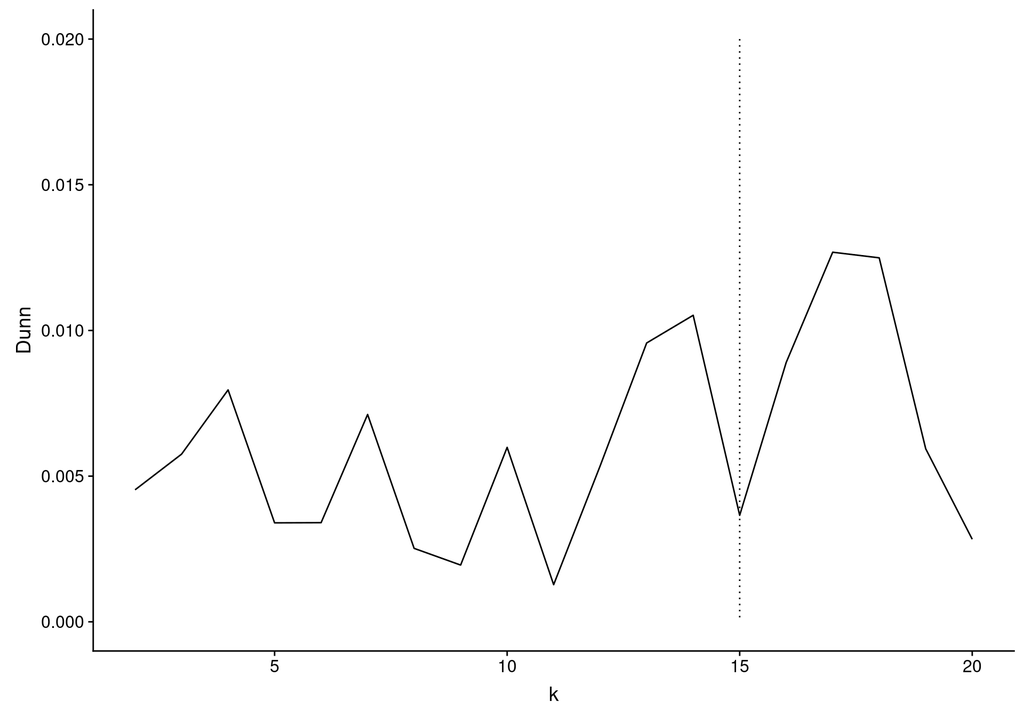

```r
ggplot(data = inds %>%
         filter(method == "kmeans"),
       aes(x = k, y= Dunn)) +
  geom_line() +
  geom_line(data = data.frame(x = c(15,15), y = c(0.02, 0)), aes(x = x, y = y),
            linetype = "dotted", inherit.aes = FALSE)
```

Tym razem indeks Dunna zachowuje się bardziej zgodnie z pozostałymi.

# 4 Wnioski

- Indeksy w ogólności są całkiem zgodne, choć jednak nie w stu procentach.
- Nawet jeśli znamy zadaną z góry liczbę klastrów, to indeksy mogą dawać lepsze wyniki dla innej liczby – to kwestia danych oraz algorytmu (w szczególności w tym przypadku `kmeans`).
- Pomimo że indeks Randa wymaga “prawdziwego” zaetykietowania danych (indeks zewnętrzny), a indeks gamma etykiet nie wymaga (indeks wewnętrzny), oba dają bardzo podobne rezultaty. Niestety, nie mają one aż takiej zmienności jak pozostałe indeksy i trudno wyróżnić wyraźne globalne maksimum.
- Podobnie rzecz się ma z indeksami Jaccarda/Folkesa-Mallowsa (zewnętrzne) oraz Daviesa-Bouldina (wewnętrzny) – w pewnym stopniu dają one podobne wyniki, choć tutaj podobieństwo jest już mniejsze. W okolicy “prawdziwego” *k* pierwsze dwa indeksy osiągają lokalne minima tam, gdzie trzeci osiąga lokalne maksima i vice-versa (co oznacza, że niosą podobną informację – Jaccarda/Folkesa-Mallowsa staramy się maksymalizować, Daviesa-Bouldina – minimalizować). Globalne ekstrema przyjmują jednak w różnych punktach.
- Wydaje się, że przy ostatecznym wyborze algorytmu/parametru należy się sugerować więcej niż jedną miarą i spojrzeć na co najmniej kilka indeksów. Jeśli posiadamy etykiety, najlepiej jest się sugerować nimi, choć to raczej rzadki przypadek.

# 5 Porównanie implementacji

Jako że paczkę `clusterCrit` odkryłem dopiero po zaimplementowaniu samodzielnie kryteriów zewnętrznych, poniżej umieszczam jeszcze dowód, że implementacja jest poprawna - porównanie wyników wyliczania indeksów za pomocą funkcji własnych oraz funkcji z paczki:

```r
calculate_differences <- function(dataset, P_parts, hclust_partitioning, kmeans_partitioning, own_inds) {
  maxclust <- 19
  method <- rep(c("hclust", "kmeans"), each = maxclust)
  k <- rep(2:(maxclust+1), 2)
  ret <- data.frame(method = method, k = k)
  for(k in 1:maxclust) {
    C_parts <- hclust_partitioning[[k]]
    ret[k, c("Rand", "Jaccard", "Folkes-Mallows")] <-
      unlist(clusterCrit::extCriteria(
          P_parts,
          C_parts,
          c("Rand", "Jaccard", "Folkes_Mallows")
      ))
    C_parts <- kmeans_partitioning[[k]]$cluster
    ret[k + maxclust, c("Rand", "Jaccard", "Folkes-Mallows")] <-
      unlist(clusterCrit::extCriteria(
        P_parts,
        C_parts,
        c("Rand", "Jaccard", "Folkes_Mallows")
      ))
  }
  ret[,3:5] <- ret[,3:5] - own_inds[,3:5]
}

inds2 <- calculate_differences(dataset[,1:2], dataset$label,
                               hclust_partitioning, kmeans_partitioning, inds)

inds2 %>%
  kable(digits = 15) %>%
  kable_styling(bootstrap_options = "striped", full_width = F)
```

| Rand | Jaccard | Folkes-Mallows |
| --- | --- | --- |
| -1.418577e-08 | -4.583118e-09 | 7.675923e-09 |
| -8.295822e-09 | -6.680930e-09 | -1.257407e-08 |
| -2.668552e-09 | 2.365884e-09 | -6.153200e-11 |
| 5.544589e-09 | -8.087271e-09 | 2.546221e-08 |
| -1.926151e-08 | 2.616838e-09 | 4.931259e-08 |
| -6.880649e-09 | -9.056050e-09 | 3.684891e-08 |
| 2.703385e-08 | 2.641800e-09 | 1.225815e-08 |
| -1.811991e-08 | 2.128638e-09 | 1.826831e-08 |
| 1.600929e-09 | 8.332542e-09 | 1.068343e-08 |
| 1.497644e-09 | -1.194561e-08 | 5.618117e-08 |
| 1.151021e-08 | 9.405091e-09 | 1.040972e-08 |
| 1.747363e-08 | -1.122487e-08 | 9.237569e-09 |
| 2.234047e-08 | -1.541149e-08 | 4.231110e-08 |
| -4.247447e-09 | -2.796708e-08 | 2.050801e-08 |
| -1.684812e-08 | -2.169246e-08 | -1.526539e-08 |
| -6.398813e-09 | 1.317994e-08 | -6.433983e-08 |
| -9.740110e-10 | 1.115402e-08 | -1.723618e-08 |
| -5.616854e-09 | -6.881513e-09 | 2.389031e-08 |
| 2.392429e-08 | 1.553450e-08 | -3.094341e-09 |
| -1.986050e-08 | -7.313211e-09 | -5.829353e-09 |
| 2.598660e-08 | -2.578817e-09 | 2.977428e-08 |
| 2.962640e-08 | 1.178250e-10 | 2.161551e-09 |
| -8.898378e-09 | -7.221888e-09 | -2.481990e-08 |
| -9.040275e-09 | 6.356864e-09 | 2.656960e-08 |
| 1.532571e-08 | 9.067377e-09 | 5.452846e-09 |
| 9.597581e-09 | -2.358255e-09 | -2.682128e-08 |
| -8.645528e-09 | -1.041585e-08 | 1.865150e-08 |
| -1.537444e-08 | 6.268524e-09 | 7.448223e-09 |
| -2.263362e-08 | 1.346033e-08 | 3.080781e-08 |
| 3.109486e-09 | 9.644309e-09 | 2.684033e-08 |
| 7.980608e-09 | -1.179927e-09 | -1.519862e-08 |
| 1.938578e-08 | 4.737568e-09 | 3.655726e-08 |
| -1.290595e-08 | 1.603374e-08 | -4.312965e-09 |
| -4.377211e-09 | 2.055298e-08 | -3.845654e-08 |
| 1.137204e-08 | 1.106601e-08 | -2.447919e-08 |
| -2.295398e-08 | 1.528748e-08 | -2.230308e-08 |
| -1.702651e-08 | 2.189381e-09 | 2.336226e-08 |
| 1.690146e-08 | 5.185755e-09 | 1.674157e-08 |

Jak widzimy, błędy są bliskie zeru i wynikają prawdopodobnie są kwestii numerycznych (jak np. kolejność obliczeń), których nie optymalizowałem.